# Assignment 4 - Unsupervised Learning and More Supervised Learning

## *Zhuangdie Alan Zhou*

Netid: *zz161*

## 1

### [35 points] Clustering

**(a)** Implement your own k-means algorithm. Demonstrate the efficacy of your algorithm on the `blobs` dataset from `scikit-learn` with 2 and 5 cluster centers. For each implementation rerun the k-means algorithm for values of k from 1 to 10 and for each plot the "elbow curve" where you plot the sum of square error. For each case, where is the elbow in the curve? Explain why.

**(b)** Briefly explain in 1-2 sentences each (and at a very high level) how the following clustering techniques work and what distinguishes them from other clustering methods: (1) k-means, (2) agglomerative clustering, (3) Gaussian mixture models, (4) DBSCAN, and (5) spectral clustering

- Aggregation.txt
- Compound.txt
- D31.txt
- jain.txt

Each file has three columns: the first two are $x_1$ and $x_2$, then the third is a suggested cluster label (ignore this third column - do NOT include this in your analysis). *The data are from https://cs.joensuu.fi/sipu/datasets/*.

**ANSWER**

(a)

```python
from sklearn.datasets.samples_generator import make_blobs
import numpy as np
import matplotlib.pyplot as plt
import warnings
warnings.simplefilter('ignore')
```

```python
def dis(p, points):
    '''Return the cluster of a point with minimum distance from one point to other points'''
    distance = np.sqrt(np.sum(np.square(points - p),axis = 1))
    return np.argmin(distance),float(min(distance))
```

```python
def Kmeans_Cluster(X, k, max_iter=300):
    '''A function of implementing kmean cluster that returns assigned clusters of each data point'''
    bestinitial = []
    best =[]
    for i in range(20):
        idx = np.random.choice(np.arange(len(X)), k, replace=False)
        centroids = X[idx]
        maxn = 0
        y = np.zeros(shape = (X.shape[0],1),dtype = int)
        distance = np.zeros(shape = (X.shape[0],1))
        yold = np.random.rand(X.shape[0])
        while maxn < max_iter and np.sum(y - yold)!= 0:
            yold = y.copy()
            for i in range(0, len(X)):
                y[i] = dis(X[i], centroids)[0]
                distance[i] = np.square(dis(X[i], centroids)[1])
            for j in range(0,len(centroids)):
                centroids[j] = np.mean(X[np.argwhere(y == j)[:,0]], axis = 0)
            maxn += 1
        best.append((y, sum(distance),centroids))
    y_final = min(best,key = lambda x: x[1])[0]
    sqerror = min(best,key = lambda x: x[1])[1]
    centroids = min(best,key = lambda x: x[1])[2]
    #plt.scatter(X[:,0],X[:,1],edgecolor = 'None',c = 'yellow')
    #plt.scatter(centroids[:,0],centroids[:,1],c = 'red',edgecolor = 'None')
    return X, y_final, float(sqerror)
```

```python
X = make_blobs(random_state=409)[0]
```

```python
%time
xx, yy, sqerror = Kmeans_Cluster(X, 2, max_iter=300)
```

```
CPU times: user 0 ns, sys: 0 ns, total: 0 ns
Wall time: 11.7 µs
```

```python
%time
xx, yy, sqerror = Kmeans_Cluster(X, 5, max_iter=300)
```

```
CPU times: user 0 ns, sys: 0 ns, total: 0 ns
Wall time: 11.9 µs
```

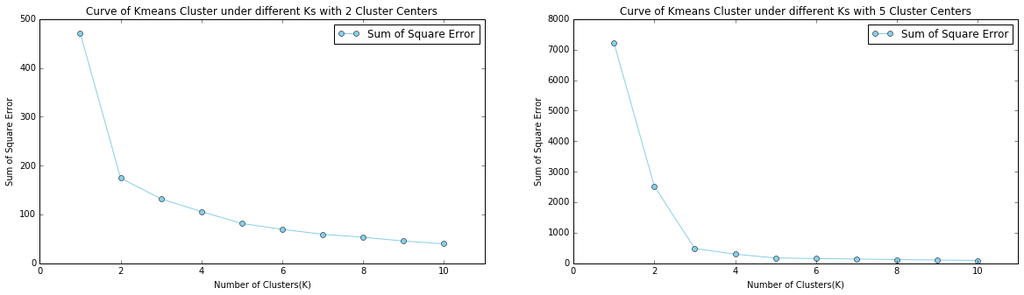

```python
X1 = make_blobs(random_state=409,centers = 2)[0]
X2 = make_blobs(random_state=409,centers = 5)[0]
k = []
error1 = []
error2 = []
for i in range(1, 11):
    x1, y1, sqerror1 = Kmeans_Cluster(X1, i, max_iter=300)
    x2, y2, sqerror2 = Kmeans_Cluster(X2, i, max_iter=300)
    k.append(i)
    error1.append(sqerror1)
    error2.append(sqerror2)
plt.figure(figsize=(20,5))
plt.subplot(1, 2, 1)
plt.plot(np.array(k), np.array(error), '-b', marker = 'o', color = 'skyblue', label = 'Sum of Square Error')
plt.xlim(0,11)
plt.ylim(0,500)
plt.xlabel('Number of Clusters(K)')
plt.ylabel('Sum of Square Error')
plt.title('Curve of Kmeans Cluster under different Ks with 2 Cluster Centers')
plt.legend()

plt.subplot(1, 2, 2)
plt.plot(np.array(k), np.array(error2), '-b', marker = 'o', color = 'skyblue', label = 'Sum of Square Error')
plt.xlim(0,11)
plt.ylim(0,8000)
plt.xlabel('Number of Clusters(K)')
plt.ylabel('Sum of Square Error')
plt.title('Curve of Kmeans Cluster under different Ks with 5 Cluster Centers')
plt.legend()
plt.show()
```

For the dataset with 2 cluster centers, elbow in the curve is at k = 2. Because from k = 1 to k = 2, the curve is the steepest, which means the sum of square error decreases most when k increases from 1 to 2. But as k increases after 2, sum of square error does not decrease much, on the contrast as k grows up there will be more risk of overfitting.

(b)

(1) k-means

a. First determine number of clusters K

b. Choose K random points as the initial means

c. Assign all the rest points to its closest mean

d. Update the means to the centroid of the labeled data

e. Iterate by repeating step c and step d until means do not change anymore(converge)

We assume the clusters are Gaussians centered at the mean, each with identical covariance matrices where all the features all independent. Therefoer K-means is good at clusters with equal variance while struggles when there are nonlinear boundaries between clusters and when there is variation in cluster variances and correlation between features.

(2) Agglomerative clustering

a. Select a measure of distance metric between points and linkage criterion between groups

b. Set each data point as a unique cluster

c. Group the two closest clusters together using the chosen distance metric

d. Group the two closest groups together using the chosen linkage criterion

e. Repeat step d until there is only one cluster

f. Cut the dendrogram with desired number of clusters

Agglomerative clustering requiring manually choose where to cut the dendrogram. Therefore it performs well when clusters are clearly separated while struggles when intercluster distance is not sufficient to distinguish clusters.

(3) Gaussian mixture models

a. Fit a weighted average of density functions to the data assuming likelihood of data is Gaussian by maximizing likelihood

b. Calculate the probability of each data point explained by each cluster(Gaussian distributions), aka responsibilities

c. Use the responsibilities to update the model to maximize the log likelihood

d. Repeat step c and step d until converge

We don't assume the clusters are Gaussians centered at the mean, each with identical covariance matrices. Therefore GMM excels when there is equality or variation in cluster variances and correlation between features while struggles when clusters are not approximately Gaussian.

(4) DBSCAN

a. Choose a distance measure, the radius of a neighbor and minPts, the number of points for a point to be a core point

b. Use the chocies in step a to assign core points(a point with at least minPts neighbors), border points(a non-core point that neighbors a core point) and noise points(other points)

c. Group neighbor core points

d. Add borders points that are neighbors of core points to the clusters

In DBSCAN, the number of cluster is chosen as part of the algorithm so it can find arbitary shaped cluster and robust to outliers. Therefore, DBSCAN work well for all shapes of clusters when density of clusters are close but cannot handle significant variation in cluster density.

(5) Spectral clustering

a. Construct an affinity matrix on the data

b. Get the principle components of the affinity matrix and reduce the dimension of the data

c. Conduct clustering in this space

Spectral clustering makes few assumptions of the data and requrie specifying numbers of clusters, it performs well for almost most kinds of datasets.

(c)

```python
import pandas as pd
from sklearn.cluster import KMeans
from sklearn.cluster import AgglomerativeClustering
from sklearn.mixture import GaussianMixture
from sklearn.cluster import DBSCAN
from sklearn.cluster import SpectralClustering
```

```python
aggregation = pd.read_table('Aggregation.txt', names = ['x1','x2','y'])
compound = pd.read_table('Compound.txt', names = ['x1','x2','y'])
d31 = pd.read_table('D31.txt', names = ['x1','x2','y'])
jain = pd.read_table('jain.txt', names = ['x1','x2','y'])
datalist = [aggregation, compound, d31, jain]
```

[output not shown]

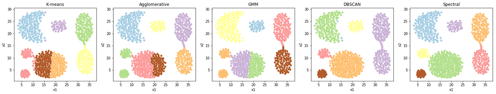

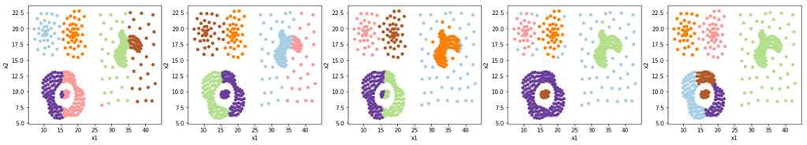

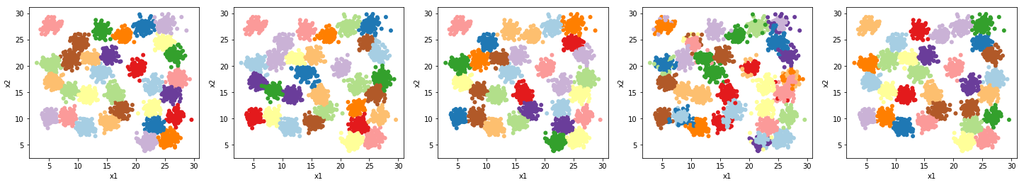

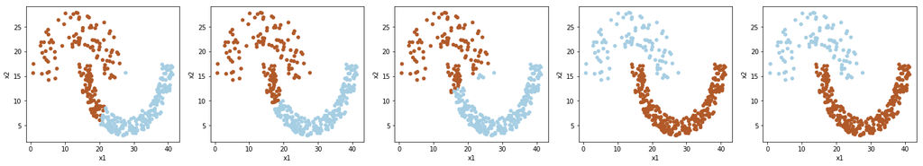

```python
%time
clusterlist = [7, 6, 31, 2]
dmbscanp = [(1.2, 5),(1.5, 4),(0.3,1),(2.5,20)]
gmm_covariancep =['full', 'spherical', 'spherical', 'tied']
j = 1
#for i in range(len(datalist)):
for i in range(len(datalist)):
    data = datalist[i]
    k = clusterlist[i]
    #KMeans
    km = KMeans(n_clusters = k ,n_init=10, random_state= 409).fit(data.iloc[:,0:2])
    kmlabels = km.labels_
    #AgglomerativeClustering
    ac = AgglomerativeClustering(k).fit(data.iloc[:,0:2])
    aclabels = ac.labels_
    #GaussianMixture
    gmm = GaussianMixture(k, n_init = 10, covariance_type= gmm_covariancep[i]).fit(data.iloc[:,0:2])
    gmmlabels = gmm.predict(data.iloc[:,0:2])
    #DBSCAN
    dbscan = DBSCAN(eps=dmbscanp[i][0], min_samples=dmbscanp[i][1]).fit(data.iloc[:,0:2])
    dbscanlabels = dbscan.labels_
    #SpectralClustering
    sc = SpectralClustering(n_clusters = k, random_state=409).fit(data.iloc[:,0:2])
    sclabels = sc.labels_

    labellist = [kmlabels, aclabels, gmmlabels, dbscanlabels, sclabels]
    titlelist = ['K-means', 'Agglomerative', 'GMM', 'DBSCAN', 'Spectral']
    plt.figure(figsize=(25, 18))
    for label in labellist:
        plt.subplot(4, 5, j)
        plt.scatter(data.iloc[:,0],data.iloc[:,1],edgecolor = 'None',c = label, cmap ='Paired')
        plt.xlabel('x1')
        plt.ylabel('x2')
        if j <= 5:
            plt.title(titlelist[j-1])
        else:
            pass
        j += 1
plt.show()
```

## 2

### [25 points] Visualizing and clustering digits with PCA and t-SNE

**(a)** Load the `scikit-learn` digits dataset. Apply PCA and reduce the data (with the associated cluster labels 0-9) into a 2-dimensional space. Plot the resulting 2-dimensional representation of the data.

**(b)** t-distributed stochastic neighborhood embedding (t-SNE) is a nonlinear dimensionality reduction technique that is particularly adept at embedding the data into lower 2 or 3 dimensional spaces. Apply t-SNE to the digits dataset and plot it in 2-dimensions (with associated cluster labels 0-9). You may need to adjust the parameters to get acceptable performance. You can read more about how to use t-SNE effectively [here](https://distill.pub/2016/misread-tsne/). A video introducing this method can be found [here](https://www.youtube.com/watch?v=RJVL80Gg3lA&list=UUtXKDgv1AVoG88PLl8nGXmw) for those who are interested.

*NOTE: An important note on t-SNE is that it is an example of transductive learning. This means that the lower dimensional representation of the data is only applicable to the specific input data - you can't just add a new sample an plot it in the sample 2-dimensional space without entirely rerunning the algorithm and finding a new representation of the data.*

**(c)** Compare/contrast the performance of these two techniques. Which seemed to cluster the data best and why? Given the comparative clustering performance that you observed and the note on t-SNE above, what are the pros and cons of PCA and t-SNE? *Note: You typically will not have labels available.*

**ANSWER**

(a)

```python
from sklearn import datasets

digits = datasets.load_digits()

x_train = digits.data
y_train = digits.target
```

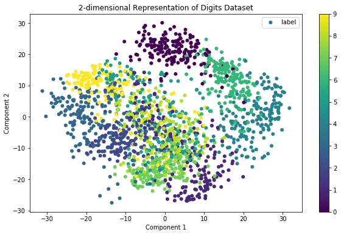

```python
pca = PCA(n_components=2)
data2d = pca.fit_transform(x_train)
plt.figure(figsize= (10,6))
plt.scatter(data2d[:,0], data2d[:,1],c = y_train, edgecolors= 'none',
              label = 'label')
plt.xlabel('Component 1')
plt.ylabel('Component 2')
# plt.xlim(-1500, 2500)
# plt.ylim(-1500, 1500)
plt.title('2-dimensional Representation of Digits Dataset')
plt.colorbar()
plt.legend()
plt.show()
```

(b)

```python
from sklearn.manifold import TSNE
X_embedded = TSNE(n_components=2,verbose=1, perplexity=40, n_iter=300).fit_transform(x_train)
```

```
[t-SNE] Computing 121 nearest neighbors...
[t-SNE] Indexed 1797 samples in 0.012s...
[t-SNE] Computed neighbors for 1797 samples in 0.368s...
[t-SNE] Computed conditional probabilities for sample 1000 / 1797
[t-SNE] Computed conditional probabilities for sample 1797 / 1797
[t-SNE] Mean sigma: 8.394135
[t-SNE] KL divergence after 250 iterations with early exaggeration: 61.469334
[t-SNE] KL divergence after 300 iterations: 0.950861
```

```python
import pandas as pd
xy = np.hstack((X_embedded, y_train.reshape(-1,1)))
xy = pd.DataFrame(xy, columns= ['x1','x2','label'])
xy.label = xy.label.astype(int)
```

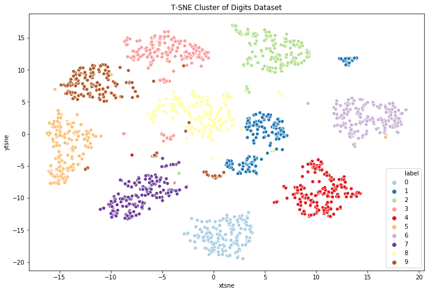

```python
import seaborn as sns
plt.figure(figsize= (12,8))
facet = sns.scatterplot(data=xy, x='x1', y='x2', hue='label',
                   legend='full', palette="Paired",)
plt.xlabel('xtsne')
plt.ylabel('ytsne')
plt.title('T-SNE Cluster of Digits Dataset')
plt.show()
```

(c)

T-SNE performed much better than PCA as for PCA clusters are blended with each other, while for t-SNE each cluster is clearly separated with each other.

#### PCA:

Pros: Perform quickly for any data analytics project which has linear data.

Cons: Produces only rotational transformation of data and is not suitable for non linear data.

#### t-SNE:

Pros: Can work well when data is strongly non-linear.

Cons: Has high time and space complexity as that of size of data.

## 3

### [30 points] PCA for compression

From the digits dataset, extract all the 5's. Your going to create a compressed version of one of an image.

**(a)** Plot a number of examples of the original images.

**(b)** Perform PCA on the data. Create a plot showing the fraction of variance explained as you incorporate from $1$ to $N$ components.

**(c)** Select an image (from your dataset of 5's) that you will "compress" using PCA. Use the principal components extracted in (b) for data compression: choose the top $k$ principal components and represent the data using a subset of the total principal components. Plot the original image, and compressed versions with different levels of compression (i.e. using different numbers of the top principal components): use $k=1,5,10,25$.

**(d)** How many principal components are required to well-approximate the data in (c)? How much compression is achieved in each case (express compression as the ratio of $k$ to the original dimension of the data $D$, so it ranges from $0$ to $1$). Comment on each case.

**ANSWER**

(a)

```python
x_train_5 = x_train[np.where(y_train == 5)]
```

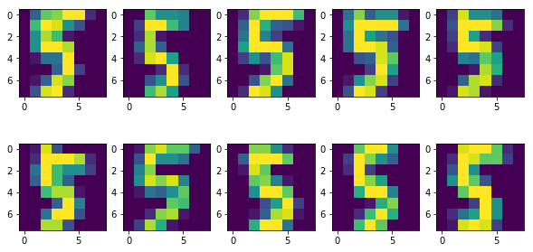

```python
fig=plt.figure(figsize=(10, 5))
columns = 5
rows = 2
for i in range(1, columns*rows +1):
    img = x_train_5[i].reshape(8, 8)
    fig.add_subplot(rows, columns, i)
    plt.imshow(img)
plt.show()
```

(b)

```python
i = 1
varl = []
tol = 1
while tol > 0.0001:
    pca2 = PCA(n_components = i)
    x_5 = pca2.fit_transform(x_train_5)
    var = pca2.explained_variance_ratio_
    varl.append((i, sum(var)))
    tol = 1 - sum(var)
    i += 1
```

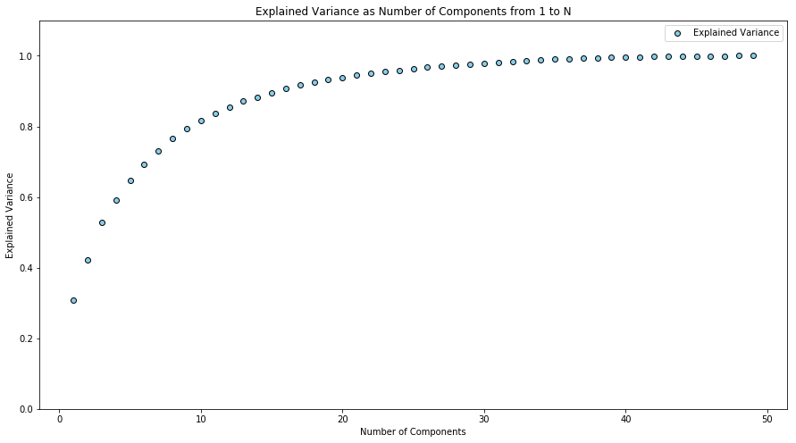

```python
v = np.array(varl)
plt.figure(figsize= (15,8))
plt.scatter(v[:,0], v[:,1],edgecolors= 'black', c = 'skyblue', label = 'Explained Variance')
plt.xlabel('Number of Components')
plt.ylabel('Explained Variance')
plt.title('Explained Variance as Number of Components from 1 to N')
#plt.xlim(-50, 500)
plt.ylim(0, 1.1)
plt.legend()
plt.show()
```

(c)

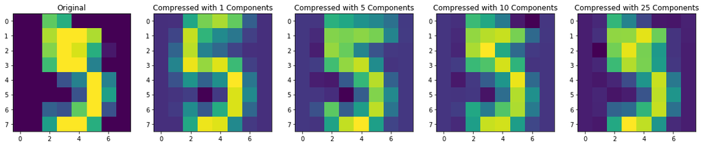

```python
compl =[1, 5, 10, 25]

imgc = x_train_5[0].reshape(8, 8)
plt.figure(figsize= (20,8))
plt.subplot(1, 5, 1)
plt.title('Original')
plt.imshow(imgc)

for i in range(0, 4):
    pca3 = PCA(n_components = compl[i])
    xc1 = pca3.fit_transform(x_train_5)
    approximation = pca3.inverse_transform(xc1)
    plt.subplot(1, 5, i+2)
    plt.imshow(approximation[0,].reshape(8,8))
    plt.title('Compressed with %d Components' % compl[i])
plt.show()
```

(d)

25 components are requried to well-approximate the data in (c)

For k = 1, ratio of compression achieved is (64 - 1)/64 = 98.44%

For k = 5, ratio of compression achieved is (64 - 5)/64 = 92.19%

For k = 10, ratio of compression achieved is (64 - 10)/64 = 84.38%

For k = 25, ratio of compression achieved is (64 - 25)/64 = 60.94%

## 4

### [15 points] Build and test your own Neural Network for classification

There is no better way to understand how one of the core techniques of modern machine learning works than to build a simple version of it yourself. In this exercise you will construct and apply your own neural network classifier.

**(a)** Create a neural network class that follows the `scikit-learn` classifier convention by implementing `fit`, `predict`, and `predict_proba` methods. Your `fit` method should run backpropagation on your training data using stochastic gradient descent. Assume the activation function is a sigmoid. Choose your model architecture to have two input nodes, two hidden layers with five nodes each, and one output node.

**(b)** Create a training and test dataset using `sklearn.datasets.make_moons(N, noise=0.20)`, where $N_{train} = 500$ and $N_{test} = 100$. Train and test your model on this dataset. Adjust the learning rate and number of training epochs for your model to improve performance as needed. In two subplots, plot the training data on one, and the test data on the other. On each plot, also plot the decision boundary from your neural network trained on the training data. Report your performance on the test data with an ROC curve.

**(c)** Suggest at least two ways in which you neural network implementation could be improved.

**ANSWER**

(a)

```python
import warnings

warnings.simplefilter('ignore')
```

```python
class Neural_NetworktestJ3(object):
    '''A Neural Network with two input nodes, two hidden layers with five nodes each, and one output node.'''
    def __init__(self):
        '''Hyperparameters'''

        self.inputlayer = 3
        self.outputlayer = 1
        self.hiddenlayer1 = 5
        self.hiddenlayer2 = 5

        self.W1 = np.random.randn(self.inputlayer, self.hiddenlayer1)
        self.W2 = np.random.randn(self.hiddenlayer1, self.hiddenlayer2)
        self.W3 = np.random.randn(self.hiddenlayer2, self.outputlayer)

    def sigmoid(self,a):
        '''Sigmoid activation function'''

        return 1/(1 + np.exp(-a))

    def sigmoidPrime(self, a):
        '''Derivative of Sigmoid activation function'''

        return np.exp(-a)/np.square(1+np.exp(-a))

    def forward(self, X):
        '''Forward feeding to initialize values'''

        self.a1 = X@self.W1
        self.z1 = self.sigmoid(self.a1)
        self.a2 = self.z1@self.W2
        self.z2 = self.sigmoid(self.a2)
        self.a3 = self.z2@self.W3
        yhat = self.sigmoid(self.a3)

        return yhat

    def costFunction(self, X, y):
        '''Cost functoin'''

        yhat = self.forward(X)
        y = y.reshape(-1 ,1)

        return 0.5*np.sum(np.square(y - yhat))

    def costFunctionPrime(self, X, y):
        '''Derivative of cost function respect to W1, W2 and W3'''

        self.yHat = self.forward(X)

        delta3 = np.multiply(-(y - self.yHat), self.sigmoidPrime(self.a3))
        dJdW3 = np.dot(self.z2.T, delta3)

        delta2 = np.dot(delta3, self.W3.T)*self.sigmoidPrime(self.a2)
        dJdW2 = np.dot(self.z1.T, delta2)

        delta1 = np.dot(delta2, self.W2.T)*self.sigmoidPrime(self.a1)
        dJdW1 = np.dot(X.T, delta1)

        return dJdW1, dJdW2, dJdW3

    def stochastic_gd(self, X, y, ita = 0.01, tol = 0.001, max_ite =100000):
        '''Stochastic gradient descent'''

        tol = 1
        cost = 0
        ite = 0
        costl =[]
        while tol > 0.001 and ite < max_ite:
            for xi, yi in zip(X, y):
                xi = xi.reshape(1, -1)
                dJdW1, dJdW2, dJdW3 = self.costFunctionPrime(xi, yi)
                self.W3 = self.W3 - ita * dJdW3
                self.W2 = self.W2 - ita * dJdW2
                self.W1 = self.W1 - ita * dJdW1
            cost0 = cost
            costl.append(cost)
            cost = self.costFunction(X, y)
            tol = abs(cost - cost0)
            ite += 1

        return self.W1, self.W2, self.W3

    def fit(self, X, y):
        self.W1, self.W2, self.W3 = self.stochastic_gd(X, y)
        pass

    def predict_proba(self, Xnew):
        '''Predict the probability of new given X'''
        yhatp = self.forward(Xnew)
        return yhatp

    def predict(self, Xnew):
        '''Predict the output of new given X'''
        yhat = self.forward(Xnew)
        yhat[np.where(yhat < 0.5)] = 0
        yhat[np.where(yhat > 0.5)] = 1

        return yhat.ravel().astype(int)
```

(b)

```python
from sklearn.datasets.samples_generator import make_blobs
train_X, train_y = make_moons(n_samples=500, noise=0.20, random_state=1234)
test_X, test_y = make_moons(n_samples=100, noise=0.20, random_state=123)
```

```python
x1 = np.linspace(-2,2.5,500)
x2 = np.linspace(-1.5,1.5,500)
x1mesh, x2mesh = np.meshgrid(x1,x2)
xmesh = np.column_stack((x1mesh.ravel(),x2mesh.ravel()))
X_xmesh = np.concatenate((xmesh[:,0].reshape(-1,1),xmesh[:,1].reshape(-1,1)),axis=1)
X_xmesh = np.concatenate((np.ones((xmesh.shape[0],1)),xmesh),axis=1)

model3 = Neural_NetworktestJ3()
model3.fit(X_,y_)
ymesh = model3.predict(X_xmesh)
ymesh = ymesh.reshape(500,500)
```

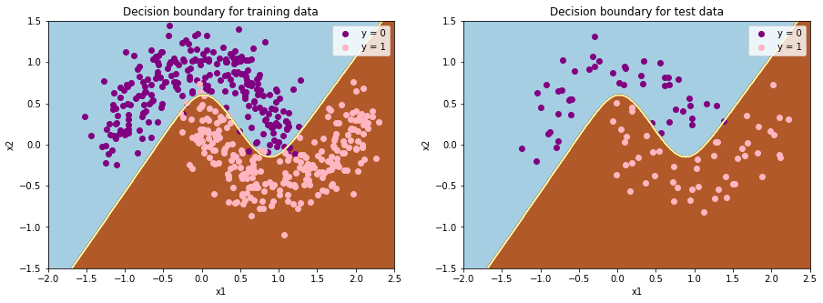

```python
plt.figure(figsize= (15,5))
plt.subplot(1, 2 ,1)
plt.contourf(x1mesh,x2mesh,ymesh,cmap=plt.cm.Paired)
plt.contour(x1mesh,x2mesh,ymesh,cmap=plt.cm.Paired)
plt.scatter(train_X[np.argwhere(train_y == 0).ravel()][:,0],
            train_X[np.argwhere(train_y == 0).ravel()][:,1],c = 'purple',label = 'y = 0')
plt.scatter(train_X[np.argwhere(train_y == 1).ravel()][:,0],
            train_X[np.argwhere(train_y == 1).ravel()][:,1],c = 'lightpink',label = 'y = 1')


plt.title('Decision boundary for training data')
plt.xlabel('x1')
plt.ylabel('x2')
plt.legend()

plt.subplot(1, 2 ,2)
plt.contourf(x1mesh,x2mesh,ymesh,cmap=plt.cm.Paired)
plt.contour(x1mesh,x2mesh,ymesh,cmap=plt.cm.Paired)
plt.scatter(X_test[np.argwhere(yhat == 0).ravel()][:,1],
            X_test[np.argwhere(yhat == 0).ravel()][:,2],c = 'purple',label = 'y = 0')
plt.scatter(X_test[np.argwhere(yhat == 1).ravel()][:,1],
            X_test[np.argwhere(yhat == 1).ravel()][:,2],c = 'lightpink',label = 'y = 1')


plt.title('Decision boundary for test data')
plt.xlabel('x1')
plt.ylabel('x2')
plt.legend()

plt.show()
```

```python
from sklearn import metrics
def plot_roc(labels, prediction_scores):
    fpr, tpr, _ = metrics.roc_curve(labels, prediction_scores, pos_label=1)
    auc = metrics.roc_auc_score(labels, prediction_scores)
    legend_string = 'AUC = {:0.3f}'.format(auc)
    plt.figure(figsize=(7,5))
    plt.plot([0,1],[0,1],'--', color='gray', label='Chance')
    plt.plot(fpr, tpr, label=legend_string)
    plt.xlabel('False Positive Rate')
    plt.ylabel('True Positive Rate')
    plt.title('ROC Curve and AUC')
    plt.grid('on')
    plt.legend(loc =4)
    plt.tight_layout()
    plt.show()
```

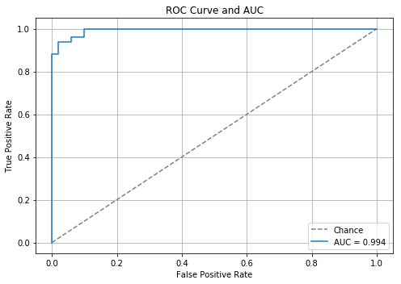

```python
yhatp = model3.predict_proba(X_test)
plot_roc(test_y, yhatp)
```